# DA 5: Profile Analysis

Anish Yakkala

```r
## IGNORE THIS
options(digits=3)
#knitr::opts_chunk$set(fig.width=4, fig.height=4)
#install.packages("tidyverse")
library(dplyr)
library(ggplot2)
library(tidyr)
library(Hotelling)
```

# The Data

Our dataset in this lab concerns the popularity of names for babies in the United States since 1996. You can also download the datasets you need individually from https://www.dropbox.com/sh/czm61yzmvzl6xfb/AABEFdpy02aNRhZ_vcxrVAQSa?dl=0

The data is very large, so it has been split by the first letter of the names. We will begin by examining my name - then you will be able to look at your own!

To load the file for “K” names into R, you will need to find the *path*; that is, the series of folders it is stored in. Most likely, this looks something like:

```
/Users/yourname/Documents/Stat_419_Labs/BabyNames/StateNames_K.csv
```

You can left-click the file, and select “Get Info” (Mac) or “Get Properties” (PC) to find the exact path, if you are unsure.

The following code loads the data (from my own path) and narrows it down to only the name “Kelly”. For convenience, we will look only at female babies named Kelly for now.

```r
my_path = "BabyNames/"

knames <- read.csv(paste(my_path, "StateNames_K.csv", sep = ""))

kellys <- knames %>%
  filter(Name == "Kelly", Gender == "F") %>%
  select(-Gender)

summary(knames)
```

```
##       Name             Year      Gender        State           Count
##  Kendall:  1292   Min.   :1997   F:90184   CA     : 9394   Min.   :   5
##  Kennedy:  1042   1st Qu.:2001   M:47551   TX     : 9374   1st Qu.:   6
##  Kayden :  1016   Median :2006             FL     : 6282   Median :  10
##  Keegan :   975   Mean   :2006             NY     : 5861   Mean   :  24
##  Kelly  :   958   3rd Qu.:2010             GA     : 5213   3rd Qu.:  20
##  Kyle   :   950   Max.   :2014             IL     : 5146   Max.   :2562
##  (Other):131502                            (Other):96465
```

Edit the code above as needed, so that you have downloaded the “K Names” dataset and loaded it from your own path.

What variables are in the dataset `knames`? What do these measure?

```
Name - Names of babies in the U.S since 1996 that start with the letter "K"
Year - Specific year in which the count of that name is given
Gender - Specific gender in which the count of that name is given
State - Specific state in which the count of that name is given
Count - Count of a specific name of a specified Gender in a specified State
```

# Question I: Is my name not cool any more?

Let’s take a look at how the name “Kelly” has changed over time since 1996. The following code will plot the total counts (added up for each state) for each year.

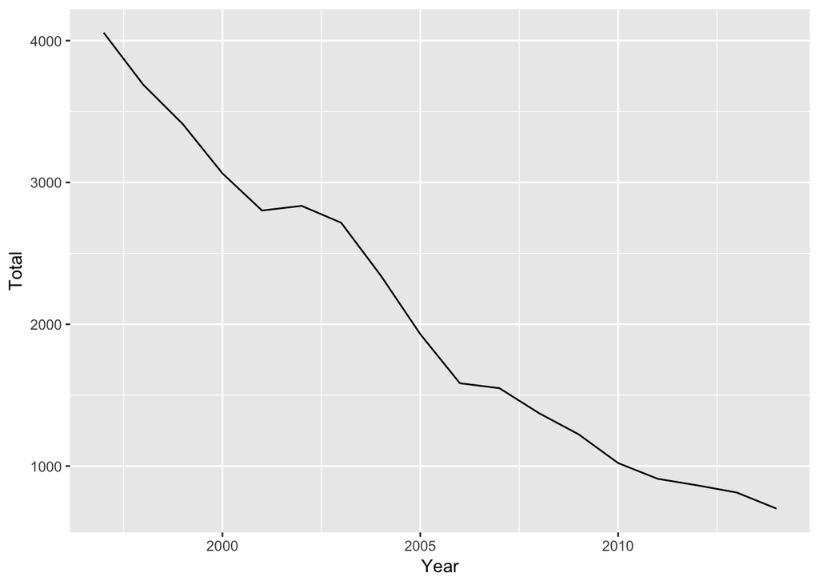

```r
# Plot Kelly count over time
kellys_by_year <- kellys %>%
  group_by(Year) %>%
  summarise(Total = sum(Count))

ggplot(kellys_by_year, aes(x = Year, y = Total)) + geom_line()
```

One approach to analyzing this data would be to run a linear regression over time, and see if the slope is negative. Use the function `lm()` to do a simple linear regression of Total Count versus Year.

```r
my_model <- lm(Total ~ Year, data = kellys_by_year)
summary(my_model)
```

```
##
## Call:
## lm(formula = Total ~ Year, data = kellys_by_year)
##
## Residuals:
##    Min     1Q Median     3Q    Max
## -365.2 -142.3  -22.3  133.8  350.4
##
## Coefficients:
##              Estimate Std. Error t value Pr(>|t|)
## (Intercept) 403043.61   18695.37    21.6  3.0e-13 ***
## Year          -199.95       9.32   -21.4  3.2e-13 ***
## ---
## Signif. codes:  0 '***' 0.001 '**' 0.01 '*' 0.05 '.' 0.1 ' ' 1
##
## Residual standard error: 205 on 16 degrees of freedom
## Multiple R-squared:  0.966,  Adjusted R-squared:  0.964
## F-statistic:  460 on 1 and 16 DF,  p-value: 3.25e-13
```

What do you conclude from this model?

[output not shown]

We now also have the tool of Profile Analysis. Here, we will treat each year as a separate element of a large multivariate random variable. In each year, we have 51 observations: one from each state (plus Washington DC). We will consider the states to be independent samples.

On a separate piece of paper, write down the null and alternate hypothesis for testing “flatness”; that is, for checking whether the name “Kelly” has changed in popularity over time since 1996. Be sure to specify the form of your $C$ matrix.

Now edit and run the following code to calculate the T^2 value for a Profile Analysis Hotelling’s T-test. Note that our first step is to transform the data so that the years - which we are treating as variables - are columns. *(Transforming datasets is not part of this class - I will supply you the code - but it is a useful skill to have!)*

```r
kellys_long <- kellys %>% spread(Year, Count, fill = 0)

kellys_mat = as.matrix(kellys_long[, -c(1:2)])

c1 <- diag(17)
c2 <- -diag(17)
C <- cbind(c1, rep(0, 17)) + cbind(rep(0, 17), c2)

Y <- t(C %*% t(kellys_mat))

y_bar <- C %*% as.matrix(colMeans(kellys_mat))

S_Y <- C %*% cov(kellys_mat) %*% t(C)


T2 <- t(y_bar) %*% solve(S_Y/nrow(kellys_mat)) %*% y_bar
```

As usual, we will let R do the hard work for us! Install the package “profileR”, and run the code below.

```r
#install.packages("profileR")
library(profileR)

paos(kellys_long[, -c(1:2)], scale = FALSE)
```

```
##
## Profile Analysis for One Sample with Hotelling's T-Square:
```

```
##                                               T-Squared    F df1 df2
## Ho: Ratios of the means over Mu0=1                 64.9 2.38  18  33
## Ho: All of the ratios are equal to each other      62.4 2.50  17  34
##                                               p-value
## Ho: Ratios of the means over Mu0=1             0.0150
## Ho: All of the ratios are equal to each other  0.0114
```

Which test matches the one you did by hand?

[output not shown]

What do you think the other test is checking for?

```
The other test is checking for if the name Kelly changes in popularity by a constant amount (linearly) over time.
```

Did the name “Kelly” change in popularity over time? How do you know?

[output not shown]

Did the name “Kelly” change in popularity at a *constant rate* (i.e. linearly) over time? How do you know?

```
At a significance level of 0.05 we can conclude that the popularity over time of the name "Kelly" does not change at a constant rate (linearly), since the p-value of the second test in the profile analysis is less than 0.05.
```

Now we will compare my name to the name “Hunter” (as in, Dr. Hunter Glanz, R whiz and professor extraordinaire).

Run the following code to load the counts for Hunter and plot them.

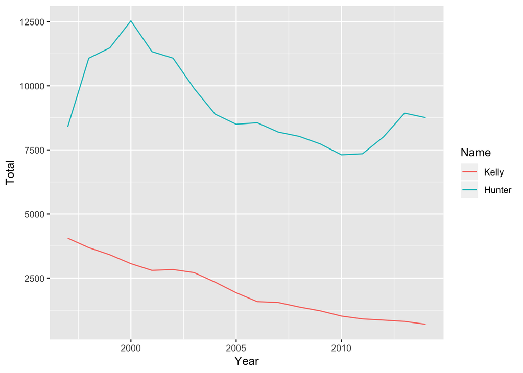

```r
hnames <- read.csv(paste(my_path, "StateNames_H.csv", sep = ""))

hunters <- hnames %>% filter(Name == "Hunter", Gender == "M") %>% select(-Gender)

hk <- rbind(kellys, hunters) %>% mutate(Name = factor(Name))

hk_by_year <-  hk %>%
  group_by(Year, Name) %>%
  summarise(Total = sum(Count))

ggplot(hk_by_year, aes(x = Year, y = Total, color = Name)) + geom_line()
```

Comment on these profile plots. Which name is more popular? Are the names changing in popularity? Are they changing at the same rate?

```
It appears that the name Hunter is more popular, that the names are changing in popularity, and that they are not changing at the same rate.
```

Now use `pbg()`, which stands for “profile by group”, to do three profile analysis tests comparing the names “Hunter” and “Kelly”.

```r
hk_long <- hk %>% spread(Year, Count, fill = 0)

my_prof <- pbg(hk_long[, -c(1:2)], group = hk_long$Name)
summary(my_prof)
```

```
## Call:
## pbg(data = hk_long[, -c(1:2)], group = hk_long$Name)
##
## Hypothesis Tests:
## $`Ho: Profiles are parallel`
##   Multivariate.Test Statistic Approx.F num.df den.df  p.value
## 1             Wilks     0.443     6.21     17     84 4.44e-09
## 2            Pillai     0.557     6.21     17     84 4.44e-09
## 3  Hotelling-Lawley     1.257     6.21     17     84 4.44e-09
## 4               Roy     1.257     6.21     17     84 4.44e-09
##
## $`Ho: Profiles have equal levels`
##              Df  Sum Sq Mean Sq F value  Pr(>F)
## group         1  505095  505095    41.6 4.1e-09 ***
## Residuals   100 1215030   12150
## ---
## Signif. codes:  0 '***' 0.001 '**' 0.01 '*' 0.05 '.' 0.1 ' ' 1
##
## $`Ho: Profiles are flat`
##      F df1 df2  p-value
## 1 6.48  17  84 1.87e-09
```

What can you conclude about the names “Hunter” and “Kelly”, and how they haved changed over time since 1996? Be specific; cite your tests!

```
At the 5% significance level we can conclude that the names "Hunter" and "Kelly" are not changing at at the same rate using the Parallelism test in the Profile by Group, which checks for parallelism, since the p-value is less than 0.05.

Since we can't assume parallism the rest will obviously be rejected. Since we know if they are not parallel it can't be that they have equal levels and that it also can't be that they both are flat.
```

# Question 2: Do these names have the same popularity in every year?

My brother Gregory is 2 years younger than me, and my cousin Erica is 5 years older than me. All of our names are going out of popularity quickly, as shown by the following plot:

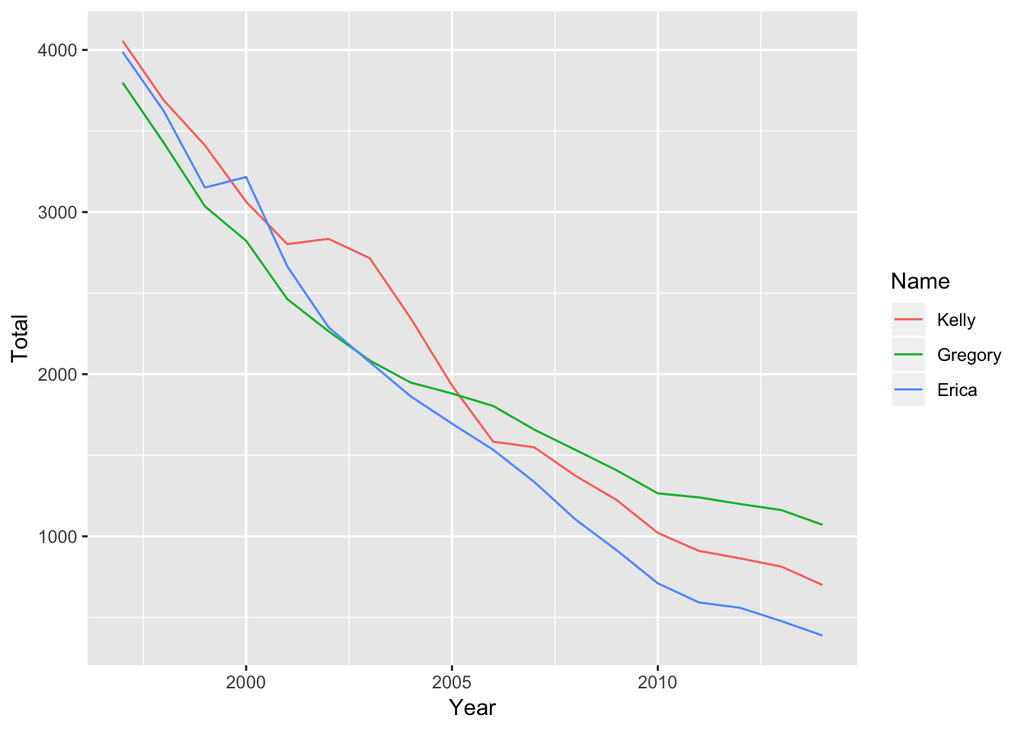

```r
gnames <- read.csv(paste(my_path, "StateNames_G.csv", sep = ""))
enames <- read.csv(paste(my_path, "StateNames_E.csv", sep = ""))

gregs <- gnames %>% filter(Name == "Gregory", Gender == "M") %>% select(-Gender)
ericas <- enames %>% filter(Name == "Erica", Gender == "F") %>% select(-Gender)

family <- rbind(kellys, gregs, ericas)

fam_by_year <-  family %>%
  group_by(Year, Name) %>%
  summarise(Total = sum(Count))

ggplot(fam_by_year, aes(x = Year, y = Total, color = Name)) + geom_line()
```

Suppose I am interested in whether our three names have equal popularity. Naively, I decide to treat each year as an independent observation. Why is this not a realistic assumption?

```
They are not independent because the count of a name in a certain year can be dependent on the count of a name in the previous year.
```

I proceed to perform an ordinary one-sample ANOVA test to see if our names have the same popularity in the 1996-2016 range.

Write down the model that is used for this test. Briefly explain what each symbol represents in terms of the data. (It is okay to write, e.g., mu_ij instead of figuring out how to use symbols. As long as I can read it!)

$\mathbb{E}(y) = \mu + \tau_{i}$

Where
$$\begin{split}
& y = \text{Average popularity of Name} \\
& \mu = \text{grand mean} \\
& \tau_{i} = \text{Treatment effect of being in group i (Kelly,Gregory,Erika)}
\end{split}$$

Now run the test:

```r
anova(lm(Count ~ Name, data = family))
```

```
## Analysis of Variance Table
##
## Response: Count
##             Df  Sum Sq Mean Sq F value Pr(>F)
## Name         2   15055    7528    2.02   0.13
## Residuals 2293 8542135    3725
```

Explain the degrees of freedom for “Name” and “Residuals”.

```
The degrees of freedom for "Name" is also the degrees of freedom for the SSR, which is the number of groups - 1.

The degrees of freedom for "Residuals" is also the degrees of freedom for the SSE, which is the n(amount of obs) - p(number of groups)
```

Report the results, including the null and alternate hypotheses, the test statistic, and the p-value. What do you conclude?

Hypothesis:

$$\begin{split}
& H_{o} : \mu_{\text{Kelly}} = \mu_{\text{Gregory}} = \mu_{\text{Erika}} \\
& \text{At least one mean is not equal to another} \\
& \alpha = 0.05
\end{split}$$

Conclusion:

At the 5% significance level we can not reject the null hypothesis that the average popularity of names for Kelly,Gregory, and Erika are all the same, since the test statisic for the test is 2.02 (df1 = 2, df2 = 2293) which leads to a p-value of 0.13 which is greater than 0.05.

Now I decide to be a good multivariate statistician, and to take into account correlation across years. For this, I will perform a MANOVA test.

What are the null and alternate hypotheses for the MANOVA test to see if our names have been equally popular across all years 1996-2016?

$$\begin{split}
& H_{o}: \vec{\mu_{\text{Kelly}}} = \vec{\mu_{\text{Gregory}}} = \vec{\mu_{\text{Erika}}} \\
& H_{a} : \text{At least one mean vector is not the same as another}
\end{split}$$

Write down the model that is used in this test. Briefly explain what each symbol represents in terms of the data.

$$\mathbb{E}(\vec{y}) = \vec{\mu} + \vec{\tau_{i}}$$

Where
$$\begin{split}
& \vec{y} = \text{Average popularity of Name for years 1997-2014} \\
& \vec{\mu} = \text{Grand Mean Vector} \\
& \vec{\tau_{i}} = \text{Treatment effect of being in group i (Kelly,Gregory,Erika)}
\end{split}$$

Note that each vector has dimension $18 \times 1$. Each row represents a year 1997-2014.

Let’s now run the manova test.

```r
fam_long <- family %>% spread(key = Year, value = Count)

fit <- manova(as.matrix(fam_long[, -c(1:2)]) ~ fam_long$Name)
summary(fit, test = "Wilks")
```

```
##               Df Wilks approx F num Df den Df  Pr(>F)
## fam_long$Name  2 0.242      3.5     36    122 1.4e-07 ***
## Residuals     78
## ---
## Signif. codes:  0 '***' 0.001 '**' 0.01 '*' 0.05 '.' 0.1 ' ' 1
```

Explain the degrees of freedom for “Name” and “Residuals”.

```
The degrees of freedom for "Name" is also the degrees of freedom for the SSR, which is the number of groups - 1.

The degrees of freedom for "Residuals" is also the degrees of freedom for the SSE, which is the n(amount of total obs) - g(number of missing obs) - p(number of groups)
```

What do you conclude about the names “Kelly”, “Gregory”, and “Erica”?

```
At least one of the names in "Kelly", "Gregory", and "Erika" is not equally popular across all years 1996-2016 as another.
```

Now check the individual ANOVA tests for each year:

```r
summary.aov(fit)
```

```
##  Response 1997 :
##               Df Sum Sq Mean Sq F value Pr(>F)
## fam_long$Name  2  39607   19803    1.71   0.19
## Residuals     78 901710   11560
##
##  Response 1998 :
##               Df Sum Sq Mean Sq F value Pr(>F)
## fam_long$Name  2  30435   15218    1.68   0.19
## Residuals     78 708388    9082
##
##  Response 1999 :
##               Df Sum Sq Mean Sq F value Pr(>F)
## fam_long$Name  2  29053   14526    1.83   0.17
## Residuals     78 620678    7957
##
##  Response 2000 :
##               Df Sum Sq Mean Sq F value Pr(>F)
## fam_long$Name  2  27242   13621    1.83   0.17
## Residuals     78 580026    7436
##
##  Response 2001 :
##               Df Sum Sq Mean Sq F value Pr(>F)
## fam_long$Name  2  21314   10657       2   0.14
## Residuals     78 416575    5341
##
##  Response 2002 :
##               Df Sum Sq Mean Sq F value Pr(>F)
## fam_long$Name  2  23913   11957    2.09   0.13
## Residuals     78 447191    5733
##
##  Response 2003 :
##               Df Sum Sq Mean Sq F value Pr(>F)
## fam_long$Name  2  25659   12829    2.39  0.098 .
## Residuals     78 417891    5358
## ---
## Signif. codes:  0 '***' 0.001 '**' 0.01 '*' 0.05 '.' 0.1 ' ' 1
##
##  Response 2004 :
##               Df Sum Sq Mean Sq F value Pr(>F)
## fam_long$Name  2  14730    7365    1.72   0.19
```

[output cut: 40 more lines]

```
## Residuals     78  64805     831
##
##  Response 2013 :
##               Df Sum Sq Mean Sq F value Pr(>F)
## fam_long$Name  2   2359    1180    1.54   0.22
## Residuals     78  59721     766
##
##  Response 2014 :
##               Df Sum Sq Mean Sq F value Pr(>F)
## fam_long$Name  2   2924    1462    2.54  0.085 .
## Residuals     78  44806     574
## ---
## Signif. codes:  0 '***' 0.001 '**' 0.01 '*' 0.05 '.' 0.1 ' ' 1
##
## 72 observations deleted due to missingness
```

What did you learn from these tests? How might this information explain your results from the univariate ANOVA test that disregarded correlation between years?

```
None of the years themselves yield significant p-values. It explains that the years are correlated with each other.
```

Finally, run the code below to replicate the analysis in Question 1, performing profile analysis on the names “Kelly”, “Greg”, and “Erica”. What do you conclude?

```r
fam_long <- family %>% spread(Year, Count, fill = 0)

my_prof <- pbg(fam_long[, -c(1:2)], group = factor(fam_long$Name))
summary(my_prof)
```

```
## Call:
## pbg(data = fam_long[, -c(1:2)], group = factor(fam_long$Name))
##
## Hypothesis Tests:
## $`Ho: Profiles are parallel`
##   Multivariate.Test Statistic Approx.F num.df den.df  p.value
## 1             Wilks     0.620     2.13     34    268 0.000507
## 2            Pillai     0.418     2.10     34    270 0.000634
## 3  Hotelling-Lawley     0.551     2.16     34    266 0.000407
## 4               Roy     0.397     3.15     17    135 0.000101
##
## $`Ho: Profiles have equal levels`
##              Df Sum Sq Mean Sq F value Pr(>F)
## group         2    765     383    0.16   0.85
## Residuals   150 364121    2427
##
## $`Ho: Profiles are flat`
##      F df1 df2  p-value
## 1 7.72  17 134 4.28e-13
```

[output not shown]

# YOUR TURN

Using the baby names data, do an analysis of your choice. See if you can find some interesting insight into the popularity of certain names!

You should include at least one profile analysis test, and at least one MANOVA test. Use R to perform the tests; you do not need to calculate test statistics by hand. You should, however, report the results in full - including the hypotheses, test statistic, p-value, and conclusion - not just supply R output.

```r
library(tidyverse)
library(data.table)
```

```r
files <- paste(my_path,"StateNames_", LETTERS,".csv", sep="")
datas <- list()
counter = 1
for (i in files){
  datas[[counter]] <- read_csv(i)
  counter <- counter + 1
}

df <- as.tibble(rbindlist(datas))
```

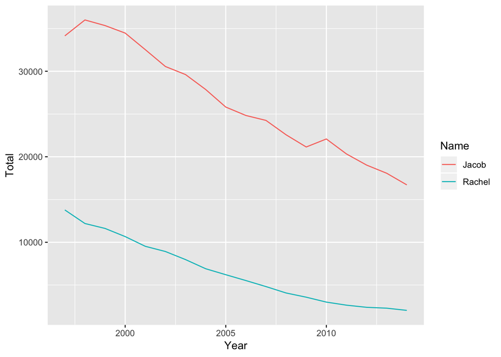

```r
religious_names <- df %>%
  filter((Name == "Jacob" & Gender == "M") | (Name == "Rachel" & Gender == "F"))

religion_by_year <- religious_names %>%
  group_by(Year, Name) %>%
  summarise(Total = sum(Count))

ggplot(religion_by_year, aes(x = Year, y = Total, color = Name)) + geom_line()
```

## MANOVA

### Hypothesis

$$\begin{split}
& H_{o}: \vec{\mu_{\text{Jacob}}} = \vec{\mu_{\text{Rachel}}} \\
& H_{a} : \text{The mean vectors are not the same.}
\end{split}$$

### Model

The model that used in this test is …

$$\mathbb{E}(\vec{y}) = \vec{\mu} + \vec{\tau_{i}}$$

Where …

$$\begin{split}
& \vec{y} = \text{Average popularity of Name for years 1997-2014} \\
& \vec{\mu} = \text{Grand Mean Vector} \\
& \vec{\tau_{i}} = \text{Treatment effect of being in group i (Jacob,Rachel)}
\end{split}$$

Note that each vector has dimension $18 \times 1$. Each row represents a year 1997-2014.

### Test

```r
religious_long <- religious_names %>%
                    select(-Gender) %>%
                    spread(key = Year, value = Count)

fit <- manova(as.matrix(religious_long[, -c(1:2)]) ~ religious_long$Name)
summary(fit, test = "Wilks")
```

```
##                     Df Wilks approx F num Df den Df Pr(>F)
## religious_long$Name  1 0.449     4.98     18     73  4e-07 ***
## Residuals           90
## ---
## Signif. codes:  0 '***' 0.001 '**' 0.01 '*' 0.05 '.' 0.1 ' ' 1
```

At the 5% significance reject the null hypothesis that the average amount of boys named Jacob is the same as the average amount of girls named Rachel for every year in 1997-2014, justified since the p-value for the MANOVA test is less than 0.05.

## Profile Analysis by Group

## Hypothesis

Parallelism:

$$\begin{split}
& H_{o} : C\vec{\mu_{\text{Jacob}}} = C\vec{\mu_{\text{Rachel}}} \\
& H_{a} : C\vec{\mu_{\text{Jacob}}} \neq C\vec{\mu_{\text{Rachel}}} \\ \\
& \alpha = 0.05/3 = 0.0167
\end{split}$$

Equal Levels:

$$\begin{split}
& H_{o} : \vec{\mu_{\text{Jacob}}} = \vec{\mu_{\text{Rachel}}} \\
& H_{a} : \vec{\mu_{\text{Jacob}}} \neq \vec{\mu_{\text{Rachel}}} \\ \\
& \alpha = 0.05/3 = 0.0167
\end{split}$$

Flatness:

$$\begin{split}
& H_{o} : C\vec{\mu_{\text{Jacob}}} = C\vec{\mu_{\text{Rachel}}} = 0 \\
& H_{a} : C\vec{\mu_{\text{Jacob}}} \neq 0 \lor C\vec{\mu_{\text{Rachel}}} \neq 0 \\ \\
& \alpha = 0.05/3 = 0.0167
\end{split}$$

```r
religious_long <- religious_names %>%
                    select(-Gender) %>%
                    spread(Year, Count, fill = 0)

religious_prof <- pbg(religious_long[, -c(1:2)], group = factor(religious_long$Name))
summary(religious_prof)
```

```
## Call:
## pbg(data = religious_long[, -c(1:2)], group = factor(religious_long$Name))
##
## Hypothesis Tests:
## $`Ho: Profiles are parallel`
##   Multivariate.Test Statistic Approx.F num.df den.df  p.value
## 1             Wilks     0.485     5.25     17     84 1.12e-07
## 2            Pillai     0.515     5.25     17     84 1.12e-07
## 3  Hotelling-Lawley     1.062     5.25     17     84 1.12e-07
## 4               Roy     1.062     5.25     17     84 1.12e-07
##
## $`Ho: Profiles have equal levels`
##              Df   Sum Sq Mean Sq F value Pr(>F)
## group         1  3860869 3860869    21.6  1e-05 ***
## Residuals   100 17908332  179083
## ---
## Signif. codes:  0 '***' 0.001 '**' 0.01 '*' 0.05 '.' 0.1 ' ' 1
##
## $`Ho: Profiles are flat`
##      F df1 df2  p-value
## 1 7.34  17  84 1.26e-10
```

At the 5% significance level we can conclude that the amount of boys named “Jacob” and amount of girls named “Rachel” are not changing at at the same rate by using the Prallelism test in the Profile by Group, which checks for parallelism, since the p-value is less than 0.05.

Since we can’t assume parallism the rest will obviously be rejected. Since we know if they are not parallel it can’t be that they have equal levels and that it also can’t be that they both are flat.